# Cereals Data

## Correlation Matrix

```
data in column(s) 'Shelf' are not numeric and were ignored
```

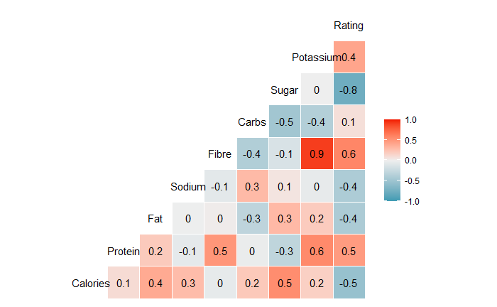

```r
cereals_data %>%
  select(Calories = Calories_100g, Protein, Fat, Sodium, Fibre, Carbs = Carbohydrates, Sugar, Potassium, Shelf, Rating) %>%
  ggcorr(label = TRUE)
```

Calories and Fat have correlation between each other(0.4) Calories and Sugar have correlation between each other(0.5) Calories and Fibre have NO correlation between each other(0)

```r
old_par<- par( mfrow = c(3,3), mfcol = c(3,3))
par(col = "red")
plot(cereals_data$Calories,cereals_data$Manufacturer,
     xlab = "Calories",ylab = "Manufacturer")+title( "Calories Vs Manufacturer")
```

```
integer(0)
```

```r
plot(cereals_data$Calories,cereals_data$Type,
      xlab = "Calories",ylab = "Type")+title("Calories Vs Type")
```

```
integer(0)
```

```r
plot(cereals_data$Calories,cereals_data$Protein,
      xlab = "Calories",ylab = "Protein")+title("Calories Vs Protein")
```

```
integer(0)
```

```r
plot(cereals_data$Calories,cereals_data$Fat,
      xlab = "Calories",ylab ="Fat")+title("Calories Vs Fat")
```

```
integer(0)
```

```r
plot(cereals_data$Calories,cereals_data$Sodium,
      xlab = "Calories",ylab = "Sodium")+title("Calories Vs Sodium")
```

```
integer(0)
```

```r
plot(cereals_data$Calories,cereals_data$Fibre,
      xlab = "Calories", ylab = "Fiber")+title("Calories Vs Fiber")
```

```
integer(0)
```

```r
plot(cereals_data$Calories,cereals_data$Carbohydrates,
      xlab = "Calories", ylab = "Carbohydrates")+title("Calories Vs Carb")
```

```
integer(0)
```

```r
plot(cereals_data$Calories,cereals_data$Sugar,
      xlab = "Calories", ylab = "Suger")+title("Calories Vs Suger")
```

```
integer(0)
```

```
integer(0)
```

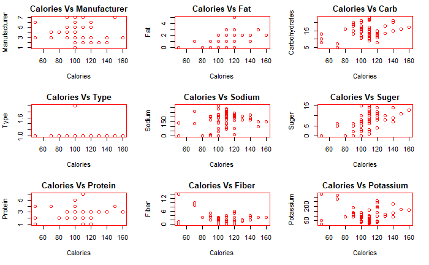

```r
plot(cereals_data$Calories,cereals_data$Potassium,
      xlab = "Calories", ylab = "Potassium")+title("Calories Vs Potassium")
```

```r
plot(cereals_data$Calories,cereals_data$Vitamins,
      xlab = "Calories", ylab = "Vitamins")+title("Calories Vs Vitamins")
```

```
integer(0)
```

```r
plot(cereals_data$Calories,cereals_data$Shelf,
      xlab = "Calories", ylab = "Shelf")+title("Calories Vs Shelf")
```

```
integer(0)
```

```r
plot(cereals_data$Calories,cereals_data$Weight,
      xlab = "Calories", ylab = "Weight")+title("Calories Vs Weight")
```

```
integer(0)
```

```r
plot(cereals_data$Calories,cereals_data$Cups,
      xlab = "Calories", ylab = "Cups")+title("Calories Vs Cups")
```

```
integer(0)
```

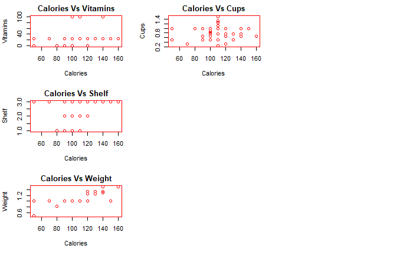

```r
par(old_par)
```

```r
NA
NA
```

## Methods for correlation analyses

There are different methods to perform correlation analysis:

1. Pearson correlation (r), which measures a linear dependence between two variables (x and y). It’s also known as a parametric correlation test because it depends to the distribution of the data. It can be used only when x and y are from normal distribution. The plot of y = f(x) is named the linear regression curve.
2. Kendall tau and Spearman rho, which are rank-based correlation coefficients (non-parametric)

**Correlation coefficient can be computed using the functions cor() or cor.test():**

cor() computes the correlation coefficient cor.test() test for association/correlation between paired samples. It returns both the correlation coefficient and the significance level(or p-value) of the correlation .

> cor(x, y, method = c(“pearson”, “kendall”, “spearman”)) cor.test(x, y, method=c(“pearson”, “kendall”, “spearman”))

x, y: numeric vectors with the same length method: correlation method

## Pearson correlation test

## Correlation test between Calories and Fat :

```r
res <- cor.test(cereals_data$Calories , cereals_data$Fat,method = "pearson")
res
```

```
    Pearson's product-moment correlation

data:  cereals_data$Calories and cereals_data$Fat
t = 4.9815, df = 75, p-value = 3.931e-06
alternative hypothesis: true correlation is not equal to 0
95 percent confidence interval:
 0.3091570 0.6499981
sample estimates:
      cor
0.4986098
```

Interpretation of the result :

The p-value of the test is 3.931e-06, which is less than the significance level alpha = 0.05. We can conclude that Calories and Fat are significantly correlated with a correlation coefficient of 0.4986098 and p-value of 3.931e-06.

Interpret correlation coefficient :

Correlation coefficient is comprised between -1 and 1:

-1 indicates a strong negative correlation : this means that every time x increases, y decreases 0 means that there is no association between the two variables (x and y) 1 indicates a strong positive correlation : this means that y increases with x

## Calories :

When assessing a food’s nutritional value, you should look at 3 things: protein, carbs, and fat. These macronutrients account for all of the calories in the item (aside from calories from alcohol). As a result, the exact amount of each macronutrient indicates what proportion of the total calories they make up

Protein: 4 kcal/g Carbohydrates: 4 kcal/g Fat: 9 kcal/g

Calories = 9 * Fat + 4 * Protein + 4 * Carbohydrates

There seem to be some mistakes in the dataset regarding calorie content. As there are products that have almost no calories (<90 kcal) and products that have close to the maximum amount of calories possible per 100g of product (900 kcal).

Since we know that fat has 9 kcal/g and protein and carbohydrates have 4 kcal/g we will recalculate the calories from the nutritional data available and replot the histogram of calories per 100g.

```r
cereals_data$Calories_100g_calculated = cereals_data$Fat_100g * 9 + cereals_data$Protein_100g * 4 + cereals_data$Carbohydrates_100g * 4
```

# Summaries Calories per 100g

[output not shown]

```r
avg_cal100 <- cereals_data %>% select(Manufacturer_Name , Calories_100g_calculated,Type) %>%
  group_by(Manufacturer_Name) %>%
  summarise(Average = round(mean (Calories_100g_calculated ,na.rm = TRUE)),
            Median = round(median(Calories_100g_calculated, na.rm = TRUE )),
              Lowest = min(Calories_100g_calculated, na.rm = TRUE),
            Highest = max(Calories_100g_calculated, na.rm = TRUE)
            )
#decres. order
avg_cal100 %>% arrange(desc(Average))
```

## Distribution of Calorie Content

**Box plot**

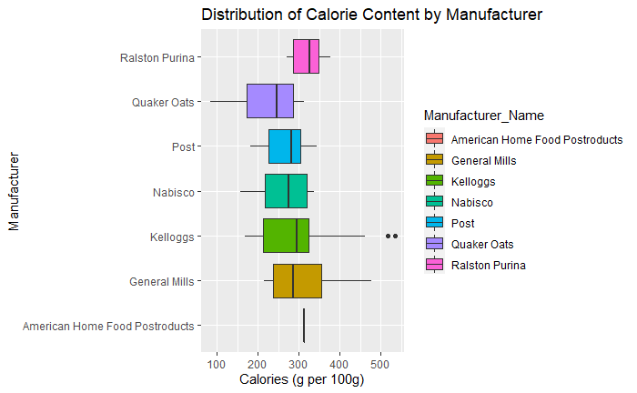

We found Average maximum Distribution of Calorie Content by Manufacturer (under 100g)is **Ralston Purina**

**Density curve**

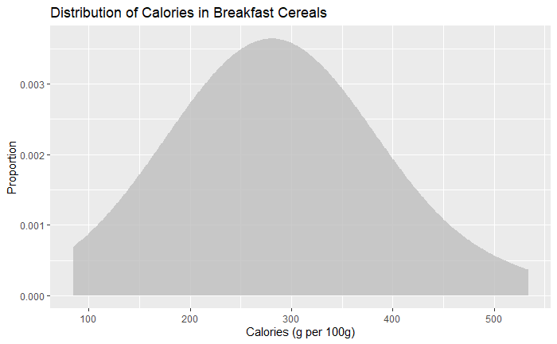

**Histogram**

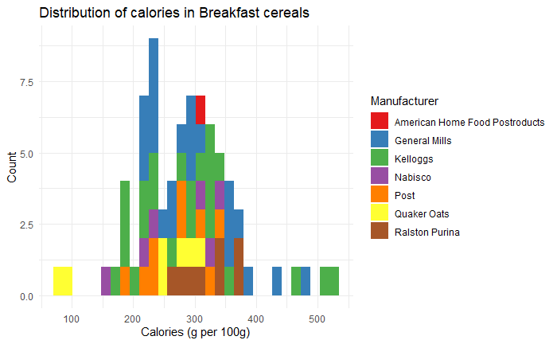

We can see the Distribution of Calorie Content by Manufacturer (under 100g) **Ralston Purina** is very strong compare to others.

Manufacturer_Name Avg Median Low High

Ralston Purina 323 325 270.7 377.0 American Home Food Postroducts 313 313 313.1 313.1

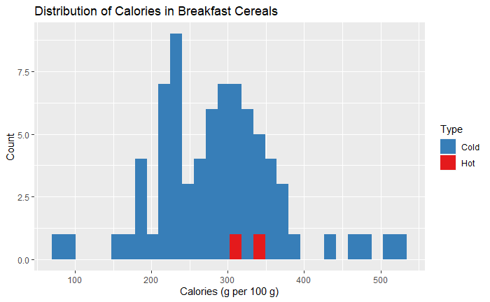

From this Histogram we can say that maximum times Cold type products gave More calories than Hot in breakfast

[output not shown]

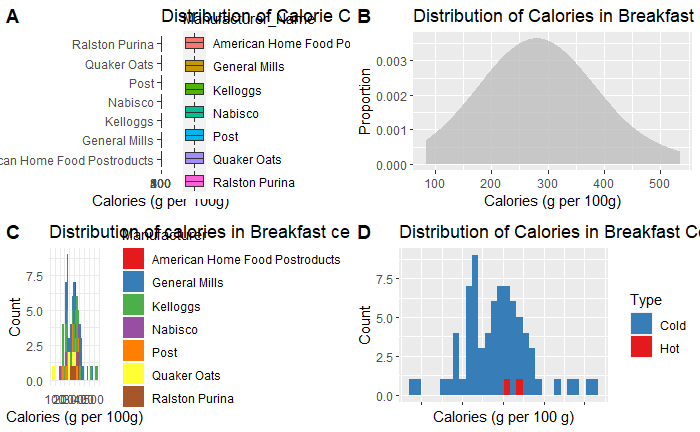

```r
ggarrange(cal_box, cal_dens,cal_hist,cal_type + rremove("x.text"),
          labels = c("A", "B", "C","D"),
          ncol = 2, nrow = 2)
```

## Fat

## Summary of Fat Content

| Product | Manufacturer | Type | Fat (g per serving) | Fat (g per ounce) | Fat (g per 100g) |
| --- | --- | --- | --- | --- | --- |
| 100% Bran | Nabisco | Cold | 1 | 1 | 3.5 |
| 100% Natural Bran | Quaker Oats | Cold | 5 | 5 | 17.6 |
| All-Bran | Kelloggs | Cold | 1 | 1 | 3.5 |
| All-Bran with Extra Fiber | Kelloggs | Cold | 0 | 0 | 0 |
| Almond Delight | Ralston Purina | Cold | 2 | 2 | 7 |
| Apple Cinnamon Cheerios | General Mills | Cold | 2 | 2 | 7 |
| Apple Jacks | Kelloggs | Cold | 0 | 0 | 0 |
| Basic 4 | General Mills | Cold | 2 | 2.66 | 9.4 |
| Bran Chex | Ralston Purina | Cold | 1 | 1 | 3.5 |
| Bran Flakes | Post | Cold | 0 | 0 | 0 |

[output cut: 67 more lines]

# Summary Table of Fat per 100g

[output not shown]

```r
avg_fat100 <- cereals_data %>%
  select(Manufacturer_Name, Fat_100g, Type) %>%
  group_by(Manufacturer_Name) %>%
  summarise(Average = round(mean(Fat_100g, na.rm = TRUE), 1),
            Median = round(median(Fat_100g, na.rm = TRUE), 1),
            Lowest = min(Fat_100g, na.rm = TRUE),
            Highest = max(Fat_100g, na.rm = TRUE),
            Count = n())
#decres. order
avg_fat100 %>% arrange(desc(Average))
```

On an Average **Quaker Oats** have more Fat in there products than others i.e 6.1

## Distribution of Fat Content

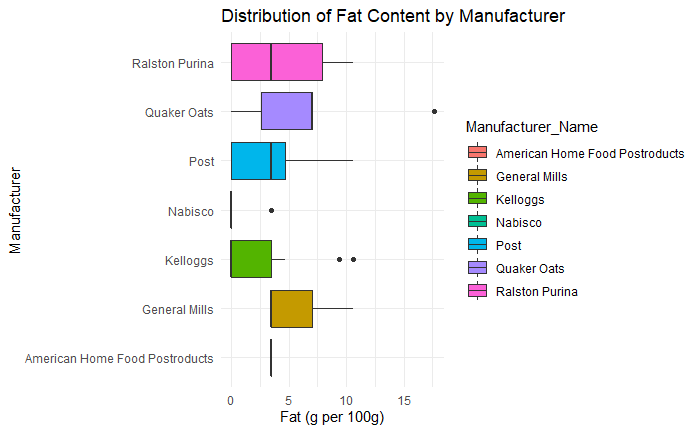

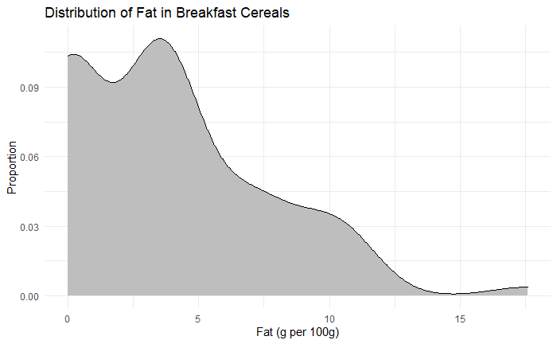

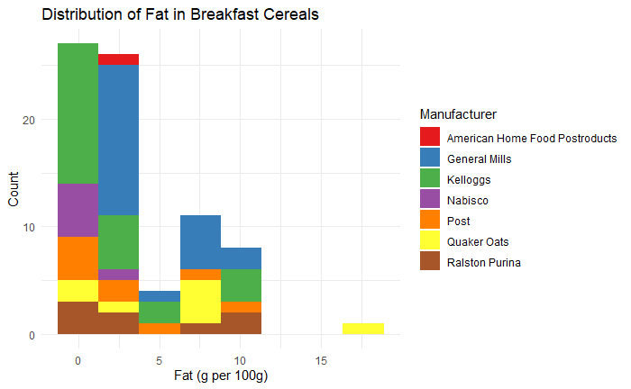

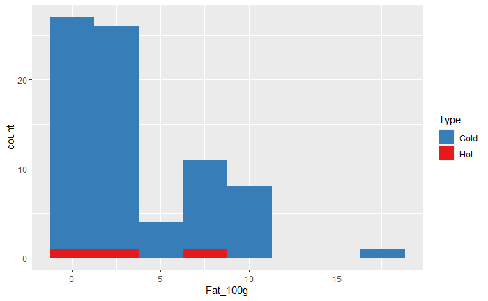

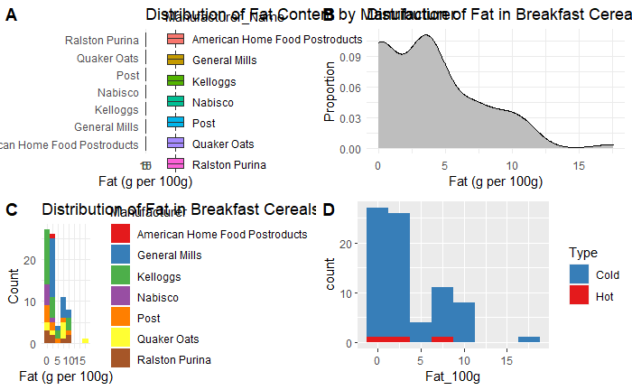

## Protein

## Summary of Protein Content

| Product | Manufacturer | Type | Protein (g per serving) | Protein (g per ounce) | Protein (g per 100g) |
| --- | --- | --- | --- | --- | --- |
| 100% Bran | Nabisco | Cold | 4 | 4 | 14.1 |
| 100% Natural Bran | Quaker Oats | Cold | 3 | 3 | 10.6 |
| All-Bran | Kelloggs | Cold | 4 | 4 | 14.1 |
| All-Bran with Extra Fiber | Kelloggs | Cold | 4 | 4 | 14.1 |
| Almond Delight | Ralston Purina | Cold | 2 | 2 | 7 |
| Apple Cinnamon Cheerios | General Mills | Cold | 2 | 2 | 7 |
| Apple Jacks | Kelloggs | Cold | 2 | 2 | 7 |
| Basic 4 | General Mills | Cold | 3 | 3.99 | 14 |
| Bran Chex | Ralston Purina | Cold | 2 | 2 | 7 |
| Bran Flakes | Post | Cold | 3 | 3 | 10.6 |

[output cut: 67 more lines]

| Manufacturer_Name | Average | Median | Lowest | Highest | Count |
| --- | --- | --- | --- | --- | --- |
| American Home Food Postroducts | 14.1 | 14.1 | 14.1 | 14.1 | 1 |
| Kelloggs | 10.1 | 10.6 | 3.5 | 21.1 | 23 |
| Nabisco | 9.8 | 10.6 | 5.8 | 14.1 | 6 |
| Post | 9.3 | 10.6 | 3.5 | 14.0 | 9 |
| Ralston Purina | 8.8 | 7.0 | 3.5 | 14.1 | 8 |
| General Mills | 8.7 | 7.0 | 3.5 | 21.1 | 22 |
| Quaker Oats | 8.6 | 7.0 | 1.8 | 17.6 | 8 |

## Distribution of Protein Content

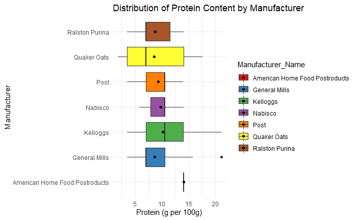

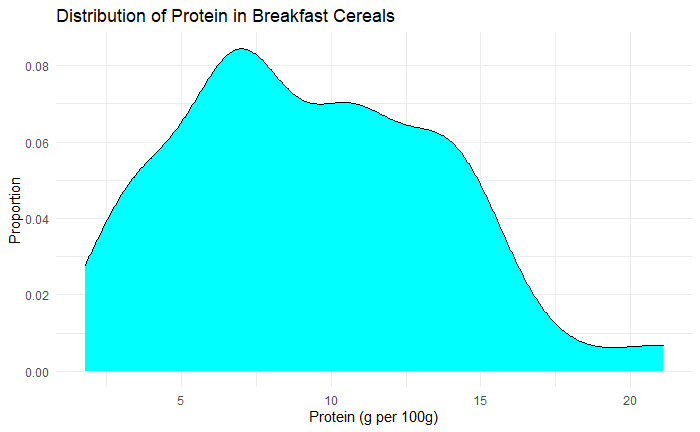

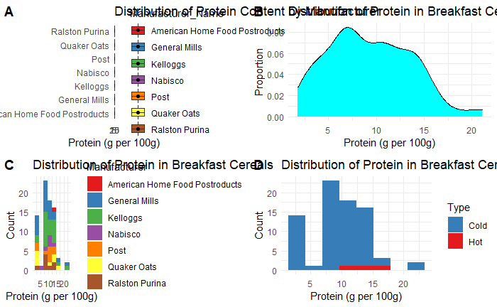

## Carbohydrates

## Summary of Carbohydrates Content

```r
cereals_data %>%
  select(Name, Manufacturer_Name, Type, Carbohydrates, Carbohydrates_oz, Carbohydrates_100g) %>%
  datatable(rownames = NULL, filter = "top", colnames = c("Product", "Manufacturer", "Type", "Carbohydrates (g per serving)", "Carbohydrates (g per ounce)", "Carbohydrates (g per 100g)"))
```

[output not shown]

| Manufacturer_Name | Average | Median | Lowest | Highest |
| --- | --- | --- | --- | --- |
| Ralston Purina | 62.0 | 58.0 | 49.3 | 81.0 |
| Kelloggs | 57.9 | 56.3 | 24.6 | 98.3 |
| American Home Food Postroducts | 56.3 | 56.3 | 56.3 | 56.3 |
| Nabisco | 54.7 | 59.9 | 17.6 | 73.9 |
| General Mills | 54.5 | 52.8 | 37.0 | 84.3 |
| Post | 49.1 | 49.3 | 38.7 | 59.8 |
| Quaker Oats | 34.9 | 42.2 | 17.6 | 49.3 |

## Distribution of Carbohydrates Content

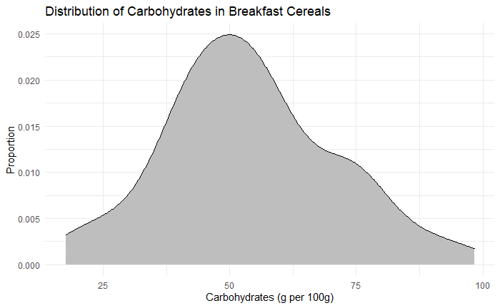

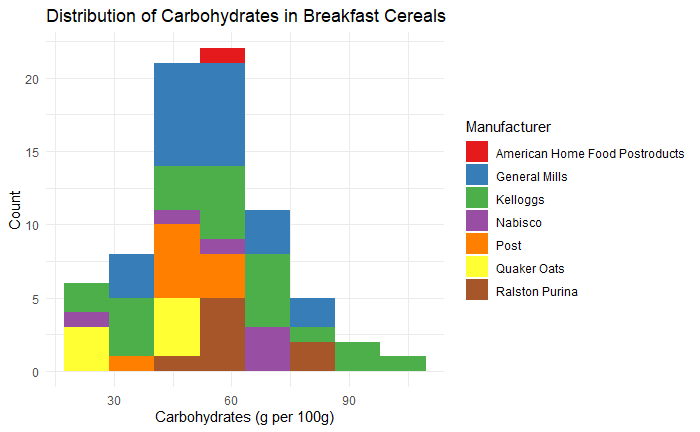

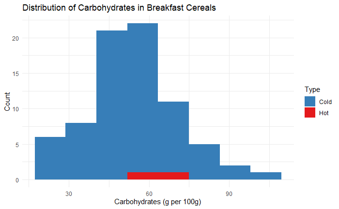

```
Removed 1 rows containing non-finite values (stat_boxplot).Removed 1 rows containing non-finite values (stat_density).Removed 1 rows containing non-finite values (stat_bin).Removed 1 rows containing non-finite values (stat_bin).
```

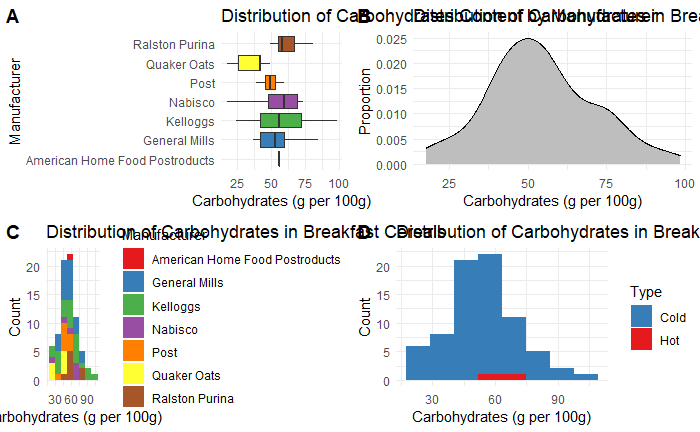

```r
ggarrange(carb_1,carb_2,carb_3,carb_4 ,labels= c("A","B","C","D"))
```

## Sugar

## Summary of Sugar Content

| Product | Manufacturer | Type | Sugar (g per serving) | Sugar (g per ounce) | Sugar (g per 100g) |
| --- | --- | --- | --- | --- | --- |
| 100% Bran | Nabisco | Cold | 6 | 6 | 21.1 |
| 100% Natural Bran | Quaker Oats | Cold | 8 | 8 | 28.2 |
| All-Bran | Kelloggs | Cold | 5 | 5 | 17.6 |
| All-Bran with Extra Fiber | Kelloggs | Cold | 0 | 0 | 0 |
| Almond Delight | Ralston Purina | Cold | 8 | 8 | 28.2 |
| Apple Cinnamon Cheerios | General Mills | Cold | 10 | 10 | 35.2 |
| Apple Jacks | Kelloggs | Cold | 14 | 14 | 49.3 |
| Basic 4 | General Mills | Cold | 8 | 10.64 | 37.5 |
| Bran Chex | Ralston Purina | Cold | 6 | 6 | 21.1 |
| Bran Flakes | Post | Cold | 5 | 5 | 17.6 |

[output cut: 67 more lines]

# Summary Table of Sugar per 100g

| Manufacturer_Name | Average | Median | Lowest | Highest |
| --- | --- | --- | --- | --- |
| Post | 33.7 | 38.7 | 10.6 | 65.5 |
| General Mills | 30.0 | 31.7 | 3.5 | 73.9 |
| Kelloggs | 29.6 | 24.6 | 0.0 | 68.6 |
| Quaker Oats | 21.6 | 21.1 | 0.0 | 42.2 |
| Ralston Purina | 21.6 | 19.4 | 7.0 | 38.7 |
| American Home Food Postroducts | 10.6 | 10.6 | 10.6 | 10.6 |
| Nabisco | 6.5 | 0.0 | 0.0 | 21.1 |

## Distribution of Sugar Content

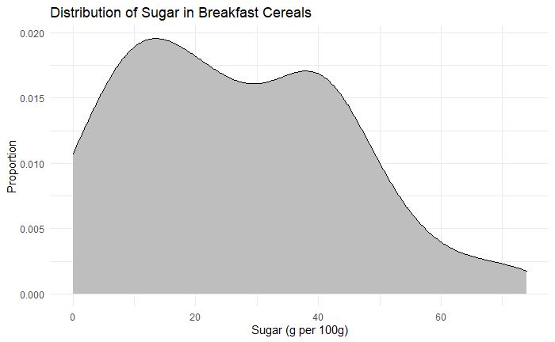

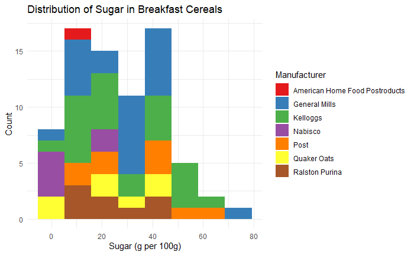

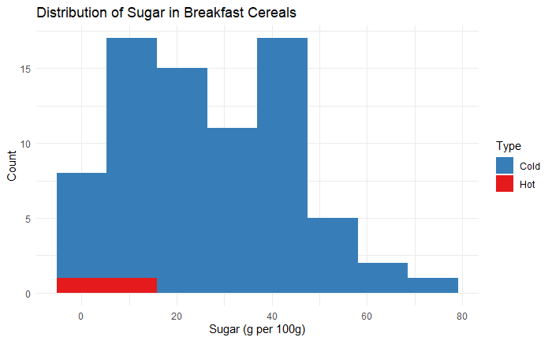

```
Removed 1 rows containing non-finite values (stat_boxplot).Removed 1 rows containing non-finite values (stat_density).Removed 1 rows containing non-finite values (stat_bin).Removed 1 rows containing non-finite values (stat_bin).
```

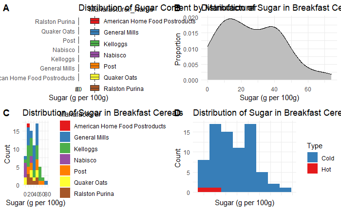

```r
ggarrange(sugar_box, sugar_dens,sugar_hist,sugar_type + rremove("x.text"),
          labels = c("A", "B", "C","D"),
          ncol = 2, nrow = 2)
```

## Fibre

## Summary of Fibre Content

```r
cereals_data %>%
  select(Name, Manufacturer_Name, Type, Fibre, Fibre_oz, Fibre_100g) %>%
  datatable(rownames = NULL, filter = "top", colnames = c("Product", "Manufacturer", "Type", "Fibre (g per serving)", "Fibre (g per ounce)", "Fibre (g per 100g)"))
```

[output not shown]

# Summary Table of Fibre per 100g

| Manufacturer_Name | Average | Median | Lowest | Highest |
| --- | --- | --- | --- | --- |
| Nabisco | 13.8 | 10.6 | 3.5 | 35.2 |
| Post | 11.1 | 10.6 | 0.0 | 28.1 |
| Kelloggs | 10.6 | 3.5 | 0.0 | 49.3 |
| Ralston Purina | 6.6 | 7.0 | 0.0 | 14.1 |
| General Mills | 5.0 | 5.3 | 0.0 | 21.1 |
| Quaker Oats | 4.5 | 5.2 | 0.0 | 9.5 |
| American Home Food Postroducts | 0.0 | 0.0 | 0.0 | 0.0 |

## Distribution of Fibre Content

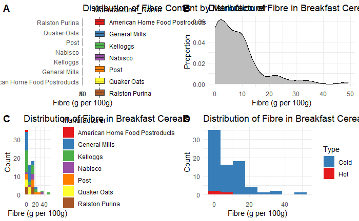

## Sodium

## Summary of Sodium Content

| Product | Manufacturer | Type | Sodium (mg per serving) | Sodium (mg per ounce) | Sodium (mg per 100g) |
| --- | --- | --- | --- | --- | --- |
| 100% Bran | Nabisco | Cold | 130 | 130 | 457.6 |
| 100% Natural Bran | Quaker Oats | Cold | 15 | 15 | 52.8 |
| All-Bran | Kelloggs | Cold | 260 | 260 | 915.2 |
| All-Bran with Extra Fiber | Kelloggs | Cold | 140 | 140 | 492.8 |
| Almond Delight | Ralston Purina | Cold | 200 | 200 | 704 |
| Apple Cinnamon Cheerios | General Mills | Cold | 180 | 180 | 633.6 |
| Apple Jacks | Kelloggs | Cold | 125 | 125 | 440 |
| Basic 4 | General Mills | Cold | 210 | 279.3 | 983.1 |
| Bran Chex | Ralston Purina | Cold | 200 | 200 | 704 |
| Bran Flakes | Post | Cold | 210 | 210 | 739.2 |

[output cut: 67 more lines]

# Summary Table of Sodium per 100g

| Manufacturer_Name | Average | Median | Lowest | Highest |
| --- | --- | --- | --- | --- |
| General Mills | 738.7 | 704.0 | 492.8 | 1020.8 |
| Ralston Purina | 697.4 | 704.0 | 334.4 | 985.6 |
| Kelloggs | 668.4 | 704.0 | 0.0 | 1126.4 |
| Post | 555.8 | 598.4 | 158.4 | 936.3 |
| Quaker Oats | 325.6 | 264.0 | 0.0 | 774.4 |
| Nabisco | 132.0 | 26.4 | 0.0 | 457.6 |
| American Home Food Postroducts | 0.0 | 0.0 | 0.0 | 0.0 |

## Distribution of Sodium Content

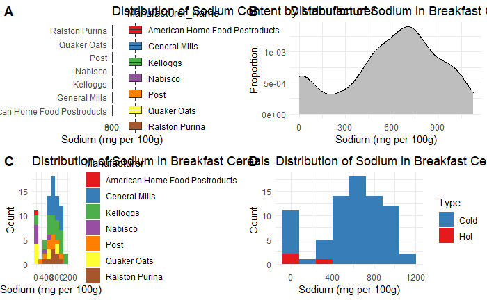

## Potassium

## Summary of Potassium Content

| Product | Manufacturer | Type | Potassium (mg per serving) | Potassium (mg per ounce) | Potassium (mg per 100g) |
| --- | --- | --- | --- | --- | --- |
| 100% Bran | Nabisco | Cold | 280 | 280 | 985.6 |
| 100% Natural Bran | Quaker Oats | Cold | 135 | 135 | 475.2 |
| All-Bran | Kelloggs | Cold | 320 | 320 | 1126.4 |
| All-Bran with Extra Fiber | Kelloggs | Cold | 330 | 330 | 1161.6 |
| Almond Delight | Ralston Purina | Cold |  |  |  |
| Apple Cinnamon Cheerios | General Mills | Cold | 70 | 70 | 246.4 |
| Apple Jacks | Kelloggs | Cold | 30 | 30 | 105.6 |
| Basic 4 | General Mills | Cold | 100 | 133 | 468.2 |
| Bran Chex | Ralston Purina | Cold | 125 | 125 | 440 |
| Bran Flakes | Post | Cold | 190 | 190 | 668.8 |

[output cut: 67 more lines]

# Summary Table of Potassium per 100g

| Manufacturer_Name | Average | Median | Lowest | Highest |
| --- | --- | --- | --- | --- |
| Nabisco | 499.0 | 422.4 | 277.6 | 985.6 |
| Post | 454.0 | 316.8 | 88.0 | 1217.2 |
| Kelloggs | 407.6 | 211.2 | 70.4 | 1161.6 |
| Ralston Purina | 359.5 | 404.8 | 88.0 | 598.4 |
| American Home Food Postroducts | 334.4 | 334.4 | 334.4 | 334.4 |
| General Mills | 328.5 | 281.6 | 88.0 | 1214.4 |
| Quaker Oats | 247.5 | 246.4 | 26.4 | 475.2 |

## Distribution of Potassium Content

```
Removed 2 rows containing non-finite values (stat_boxplot).Removed 2 rows containing non-finite values (stat_density).Removed 2 rows containing non-finite values (stat_bin).Removed 2 rows containing non-finite values (stat_bin).
```

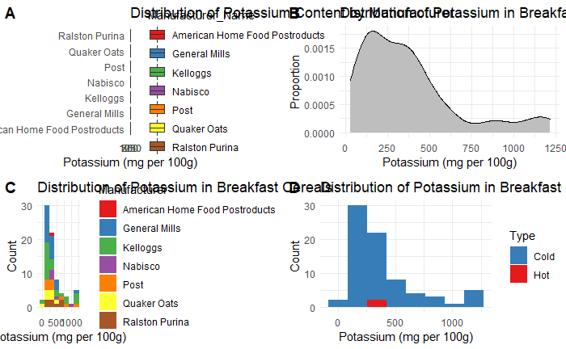

```r
ggarrange(pos_1,pos_2,pos_3,pos_4 , labels = c("A","B","C","D"))
```

ref : https://www.kaggle.com/jeandsantos/breakfast-cereals-data-analysis-and-clustering#header